# Experiment 2: Reaction Time Analyses

Owen Morgan

June 25, 2024

## Demographics

Demographics for all included participants.

Demographics

Summary

| N | Age (years) | Education (years) | Sex (M/F/O) | EHI |
| --- | --- | --- | --- | --- |
| 1,113 | 29.62 (5.85) | 14.74 (2.54) | 595/500/18 | -7.12 (77.62) |

| Handedness | N | Age (years) | Education (years) | Sex (M/F/O) | EHI |
| --- | --- | --- | --- | --- | --- |
| Left | 529 | 29.2 (5.7) | 14.94 (2.69) | 263/257/9 | -80.2 (19.39) |
| Mixed | 171 | 28.64 (6.11) | 14.78 (2.43) | 70/97/4 | -0.66 (27.16) |
| Right | 413 | 30.57 (5.81) | 14.48 (2.35) | 262/146/5 | 83.81 (17.72) |

Left: (EHI <= -40) | Mixed: (-40 < EHI < 40) | Right: (EHI >= 40)

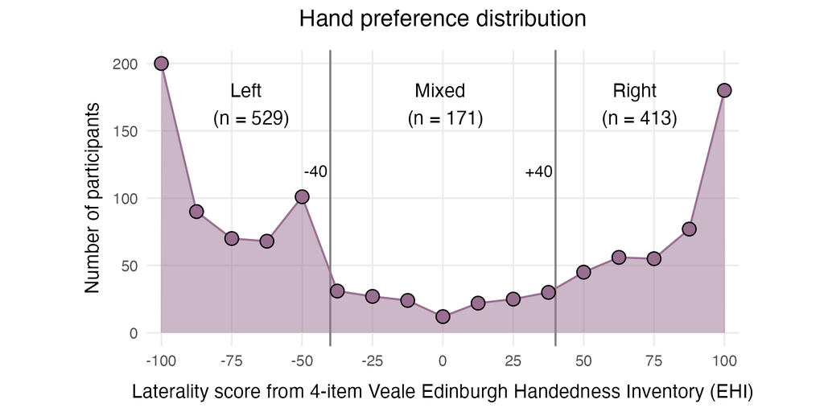

## Categorical handedness (primary)

### Summary

*When handedness is binned as left (EHI <= -40) or right (EHI > +40):*  
*Do we find an interaction of field x level x handedness?*  
*At the local level, do left handers show significantly different hemifield bias than right handers? (Local: field x handedness)*  
*At the local level, what is each group’s field bias? (Local: By handedness group, effect of field)*

For reaction time, LVF global>local bias was significantly reduced in left handers ( = 529, EHI <= -40) compared to right handers (= 413, EHI >= +40; difference between groups = 20.51ms, 95% CI [10.45, 30.57], $\chi^2(1)$ = 15.98, < .0001, two-sided). Both groups showed significant LVF global>local bias: for right handers, the effect size was 44.09ms (95% CI [36.54, 51.63], (111,144.6) = 11.46, = < .0001, two-sided); for left handers, 23.57ms (95% CI [16.92, 30.23], (111,144.1) = 6.94, < .0001, two-sided.

### Stats

Reaction time is modeled as a linear effect of field, level, and handedness, using data from every target-present trial with a “go” response:  
`lmer( rt ~ field*level*handedness + (1 | subject) )`

Experiment 2: Field by Level by Handedness (RT)

ANOVA: compare models with vs. without interaction term

| npar | AIC | BIC | logLik | deviance | Chisq | Df | p.value<sup>1</sup> |
| --- | --- | --- | --- | --- | --- | --- | --- |
| 9 | 1,523,963.01 | 1,524,049.653 | −761,972.505 | 1,523,945.01 | - | - | - |
| 10 | 1,523,949.034 | 1,524,045.304 | −761,964.517 | 1,523,929.034 | 15.976 | 1 | <.0001 |

<sup>1</sup> F-test (two-sided? https://daniellakens.blogspot.com/2016/04/one-sided-f-tests-and-halving-p-values.html)

Experiment 2: Field by Level by Handedness (RT)

Compare effect estimate to zero with emmeans()

| field_consec | level_consec | handedness_consec | estimate<sup>1</sup> | SE | df<sup>2</sup> | lower.CL<sup>3</sup> | upper.CL<sup>3</sup> | t.ratio | p.value<sup>4</sup> |
| --- | --- | --- | --- | --- | --- | --- | --- | --- | --- |
| LVF - RVF | Local - Global | Right - Left | 20.511 | 5.132 | 111,144.371 | 10.453 | 30.569 | 3.997 | <.0001 |

<sup>1</sup> A positive number means LVF global bias is stronger in right handers (as predicted by AAH)  
<sup>2</sup> Z-approximation  
<sup>3</sup> Confidence level: 95%  
<sup>4</sup> Two-sided

Experiment 2: Field by Level (by Handedness) (RT)

[output not shown]

<sup>1</sup> A positive number means global bias (faster RT for global)  
<sup>2</sup> Z-approximation  
<sup>3</sup> Confidence level: 95%  
<sup>4</sup> Two-sided, uncorrected

Experiment 2: Field by Handedess (by Level) (RT)

| field_consec | handedness_consec | level | estimate<sup>1</sup> | SE | df<sup>2</sup> | lower.CL<sup>3</sup> | upper.CL<sup>3</sup> | t.ratio | p.value<sup>4</sup> |
| --- | --- | --- | --- | --- | --- | --- | --- | --- | --- |
| LVF - RVF | Right - Left | Global | −1.793 | 3.576 | 111,142.485 | −8.801 | 5.216 | −0.501 | .616 |
| LVF - RVF | Right - Left | Local | 18.719 | 3.68 | 111,145.78 | 11.505 | 25.932 | 5.086 | <.0001 |

<sup>1</sup> A positive number means more RVF bias for right handers  
<sup>2</sup> Z-approximation  
<sup>3</sup> Confidence level: 95%  
<sup>4</sup> Two-sided, uncorrected

LVF Global bias by handedness bin (RT)

| contrast | handedness | level | estimate<sup>1</sup> | SE | df<sup>2</sup> | lower.CL<sup>3</sup> | upper.CL<sup>3</sup> | t.ratio | p.value<sup>4</sup> |
| --- | --- | --- | --- | --- | --- | --- | --- | --- | --- |
| LVF - RVF | Left | Global | −24.134 | 2.368 | 111,142.562 | −28.776 | −19.492 | −10.191 | <.0001 |
| LVF - RVF | Left | Local | −0.561 | 2.433 | 111,145.629 | −5.33 | 4.208 | −0.231 | .818 |
| LVF - RVF | Right | Global | −25.927 | 2.679 | 111,142.425 | −31.178 | −20.676 | −9.677 | <.0001 |
| LVF - RVF | Right | Local | 18.158 | 2.761 | 111,145.898 | 12.745 | 23.57 | 6.575 | <.0001 |

<sup>1</sup> A positive number means global bias (faster RT for global)  
<sup>2</sup> Z-approximation  
<sup>3</sup> Confidence level: 95%  
<sup>4</sup> Two-sided, uncorrected

### Plots

Diamonds and lineranges show mixed-effects model point estimates and 95% CI.

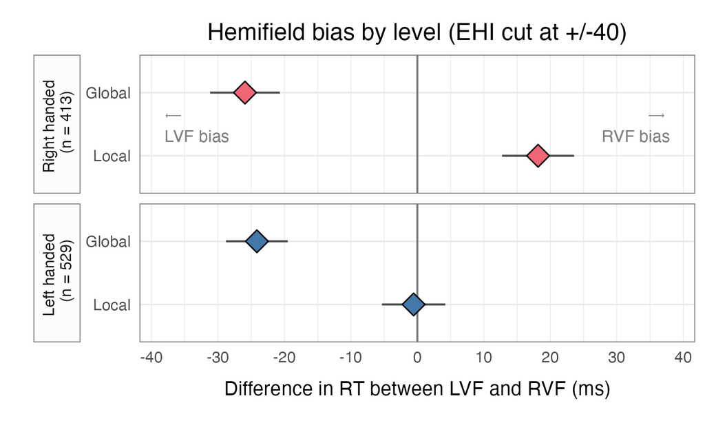

## Categorical handedness (exploratory)

### Summary

*When handedness is binned as left (EHI <= -100) or right (EHI > +100):*  
*Do we find an interaction of field x level x handedness?*  
*At the local level, do left handers show significantly different hemifield bias than right handers? (Local: field x handedness)*  
*At the local level, what is each group’s field bias? (Local: By handedness group, effect of field)*

Limiting analysis to strong left and right handers with EHI scores of +/-100, left handers’ LVF>RVF global bias was reduced by 17.44ms (95% CI [1.50, 33.38], $\chi^2(1)$ = 4.6, = .032, two-sided). Both groups showed significant LVF global>local bias: for right handers, the effect size was 36.96ms (95% CI [25.36 ,48.56], (44,479.7) = 6.25, < .0001, two-sided); for left handers, 19.52ms (95% CI [8.58, 30.45], (44,479.0) = 3.50, = .0005, two-sided).

within the local level, right and left handers showed reversed hemifield bias: right handers responded faster to local stimuli in the RVF than LVF by 9.97ms (95% CI [1.61, 18.32], (44,479.9) = 2.34, = .019, two-sided), whereas left handers responded faster to local stimuli in the LVF than RVF by 7.98ms (95% CI [0.14, 15.83], (44,479.4) = 2.00 = .046, two-sided; difference = 17.95ms, 95% CI [6.48, 29.41], (44,479.7) = 3.07, = .002, two-sided).

### Stats

Reaction time is modeled as a linear effect of field, level, and handedness, using data from every target-present trial with a “go” response:  
`lmer( rt ~ field*level*handedness + (1 | subject) )`

Experiment 2: Field by Level by Handedness (RT)

ANOVA: compare models with vs. without interaction term

| npar | AIC | BIC | logLik | deviance | Chisq | Df | p.value<sup>1</sup> |
| --- | --- | --- | --- | --- | --- | --- | --- |
| 9 | 610,761.509 | 610,839.912 | −305,371.755 | 610,743.509 | - | - | - |
| 10 | 610,758.909 | 610,846.023 | −305,369.455 | 610,738.909 | 4.6 | 1 | .032 |

<sup>1</sup> F-test (two-sided? https://daniellakens.blogspot.com/2016/04/one-sided-f-tests-and-halving-p-values.html)

Experiment 2: Field by Level by Handedness (RT)

Compare effect estimate to zero with emmeans()

| field_consec | level_consec | handedness_consec | estimate<sup>1</sup> | SE | df<sup>2</sup> | lower.CL<sup>3</sup> | upper.CL<sup>3</sup> | t.ratio | p.value<sup>4</sup> |
| --- | --- | --- | --- | --- | --- | --- | --- | --- | --- |
| LVF - RVF | Local - Global | Right - Left | 17.44 | 8.132 | 44,479.36 | 1.502 | 33.378 | 2.145 | .032 |

<sup>1</sup> A positive number means LVF global bias is stronger in right handers (as predicted by AAH)  
<sup>2</sup> Z-approximation  
<sup>3</sup> Confidence level: 95%  
<sup>4</sup> Two-sided

Experiment 2: Field by Level (by Handedness) (RT)

| field_consec | level_consec | handedness | estimate<sup>1</sup> | SE | df<sup>2</sup> | lower.CL<sup>3</sup> | upper.CL<sup>3</sup> | t.ratio | p.value<sup>4</sup> |
| --- | --- | --- | --- | --- | --- | --- | --- | --- | --- |
| LVF - RVF | Local - Global | Left | 19.518 | 5.579 | 44,479.032 | 8.582 | 30.454 | 3.498 | .0005 |
| LVF - RVF | Local - Global | Right | 36.958 | 5.916 | 44,479.652 | 25.363 | 48.553 | 6.248 | <.0001 |

<sup>1</sup> A positive number means global bias (faster RT for global)  
<sup>2</sup> Z-approximation  
<sup>3</sup> Confidence level: 95%  
<sup>4</sup> Two-sided, uncorrected

Experiment 2: Field by Handedess (by Level) (RT)

| field_consec | handedness_consec | level | estimate<sup>1</sup> | SE | df<sup>2</sup> | lower.CL<sup>3</sup> | upper.CL<sup>3</sup> | t.ratio | p.value<sup>4</sup> |
| --- | --- | --- | --- | --- | --- | --- | --- | --- | --- |
| LVF - RVF | Right - Left | Global | 0.506 | 5.651 | 44,478.812 | −10.569 | 11.582 | 0.09 | .929 |
| LVF - RVF | Right - Left | Local | 17.946 | 5.847 | 44,479.678 | 6.486 | 29.406 | 3.069 | .002 |

<sup>1</sup> A positive number means more RVF bias for right handers  
<sup>2</sup> Z-approximation  
<sup>3</sup> Confidence level: 95%  
<sup>4</sup> Two-sided, uncorrected

LVF Global bias by handedness bin (RT)

| contrast | handedness | level | estimate<sup>1</sup> | SE | df<sup>2</sup> | lower.CL<sup>3</sup> | upper.CL<sup>3</sup> | t.ratio | p.value<sup>4</sup> |
| --- | --- | --- | --- | --- | --- | --- | --- | --- | --- |
| LVF - RVF | Left | Global | −27.498 | 3.887 | 44,478.613 | −35.117 | −19.879 | −7.074 | <.0001 |
| LVF - RVF | Left | Local | −7.98 | 4.002 | 44,479.432 | −15.825 | −0.136 | −1.994 | .046 |
| LVF - RVF | Right | Global | −26.992 | 4.101 | 44,478.991 | −35.031 | −18.953 | −6.581 | <.0001 |
| LVF - RVF | Right | Local | 9.966 | 4.262 | 44,479.895 | 1.612 | 18.321 | 2.338 | .019 |

<sup>1</sup> A positive number means global bias (faster RT for global)  
<sup>2</sup> Z-approximation  
<sup>3</sup> Confidence level: 95%  
<sup>4</sup> Two-sided, uncorrected

### Plots

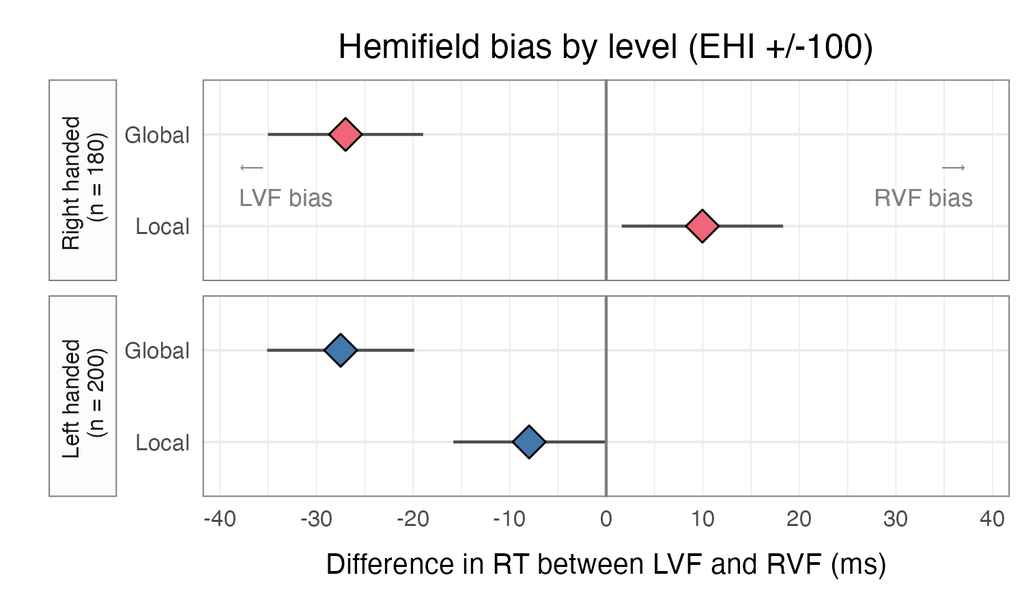

## Continuous handedness (primary)

### Summary

Do we find an interaction of field x level x handedness (continuous EHI score)?

### Stats

Model RT as a linear effect of field, level, and EHI (continuous):  
`rt_model_ehi <- lmer( rt ~ field*level*ehi + (1 | subject) )`

Experiment 2: Field by Level by EHI (RT)

ANOVA: compare models with vs. without interaction term

| npar | AIC | BIC | logLik | deviance | Chisq | Df | p.value<sup>1</sup> |
| --- | --- | --- | --- | --- | --- | --- | --- |
| 9 | 1,802,253.937 | 1,802,342.083 | −901,117.969 | 1,802,235.937 | - | - | - |
| 10 | 1,802,238.061 | 1,802,336.001 | −901,109.03 | 1,802,218.061 | 17.876 | 1 | <.0001 |

<sup>1</sup> F-test (two-sided? https://daniellakens.blogspot.com/2016/04/one-sided-f-tests-and-halving-p-values.html)

Experiment 2: Field by Level by EHI (RT)

Compare effect estimate to zero with emmeans()

| field_consec | level_consec | estimate<sup>1</sup> | SE | df<sup>2</sup> | lower.CL<sup>3</sup> | upper.CL<sup>3</sup> | t.ratio | p.value<sup>4</sup> |
| --- | --- | --- | --- | --- | --- | --- | --- | --- |
| RVF - LVF | Global - Local | 0.128 | 0.03 | 131,341.051 | 0.069 | 0.188 | 4.228 | <.0001 |

<sup>1</sup> A positive number means global bias is stronger in LVF for right handers (as predicted by AAH), in ms per EHI unit (-100 to 100). Multiply this value by 200 to get the estimated difference in LVF global bias for strong left vs. right handers.  
<sup>2</sup> Z-approximation  
<sup>3</sup> Confidence level: 95  
<sup>4</sup> Two-sided

Experiment 2: Field by EHI (by Level) (RT)

Compare effect estimate to zero with emmeans()

| contrast | level | estimate<sup>1</sup> | SE | df<sup>2</sup> | lower.CL<sup>3</sup> | upper.CL<sup>3</sup> | t.ratio | p.value<sup>4</sup> |
| --- | --- | --- | --- | --- | --- | --- | --- | --- |
| LVF - RVF | Local | 0.123 | 0.022 | 131,342.452 | 0.08 | 0.166 | 5.651 | <.0001 |
| LVF - RVF | Global | −0.005 | 0.021 | 131,339.001 | −0.047 | 0.036 | −0.249 | .803 |

<sup>1</sup> A positive number means global bias is stronger in LVF for right handers (as predicted by AAH), in ms per EHI unit (-100 to 100). Multiply this value by 200 to get the estimated difference in LVF global bias for strong left vs. right handers.  
<sup>2</sup> Z-approximation  
<sup>3</sup> Confidence level: 95  
<sup>4</sup> Two-sided

Estimated Field by Level interaction, by EHI score

| field_consec | level_consec | ehi<sup>1</sup> | estimate<sup>2</sup> | SE | df | lower.CL | upper.CL | t.ratio | p.value |
| --- | --- | --- | --- | --- | --- | --- | --- | --- | --- |
| RVF - LVF | Global - Local | −100 | 19.917 | 3.672 | 131,340.555 | 12.72 | 27.115 | 5.424 | <.0001 |
| RVF - LVF | Global - Local | 0 | 32.761 | 2.364 | 131,340.851 | 28.127 | 37.396 | 13.856 | <.0001 |
| RVF - LVF | Global - Local | 100 | 45.606 | 4.019 | 131,341.327 | 37.728 | 53.483 | 11.347 | <.0001 |

<sup>1</sup> Strong left hander: -100; Mixed hander: 0; Strong right hander: +100  
<sup>2</sup> Estimated LVF global bias (ms); a positive number means LVF global bias

Estimated global bias by field, by EHI score

| contrast | level | ehi | estimate<sup>1</sup> | SE | df | lower.CL | upper.CL | t.ratio | p.value |
| --- | --- | --- | --- | --- | --- | --- | --- | --- | --- |
| LVF - RVF | Local | −100 | −3.277 | 2.632 | 131,342.11 | −8.435 | 1.88 | −1.245 | .213 |
| LVF - RVF | Global | −100 | −23.195 | 2.561 | 131,338.958 | −28.215 | −18.175 | −9.056 | <.0001 |
| LVF - RVF | Local | 0 | 9.039 | 1.695 | 131,342.45 | 5.717 | 12.362 | 5.332 | <.0001 |
| LVF - RVF | Global | 0 | −23.722 | 1.648 | 131,338.782 | −26.952 | −20.492 | −14.393 | <.0001 |
| LVF - RVF | Local | 100 | 21.356 | 2.885 | 131,342.735 | 15.701 | 27.012 | 7.402 | <.0001 |
| LVF - RVF | Global | 100 | −24.249 | 2.797 | 131,338.885 | −29.732 | −18.766 | −8.669 | <.0001 |

<sup>1</sup> Estimated global bias (ms); a positive number means global bias

### Plots

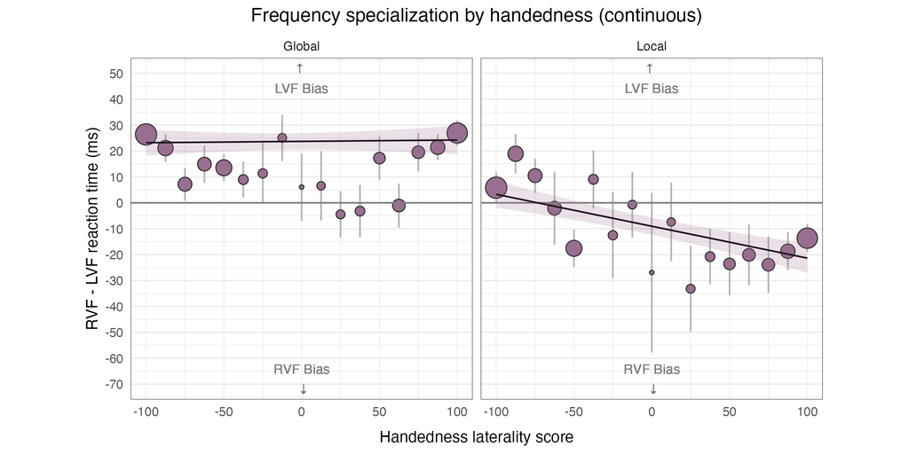